# The Parallel Universe

Finding Causal Effects by Comparing Alternate Realities

Health Economics and Policy

Spring 2026

# The Parallel Universe

DiD as a Counterfactual Bridge

## The Dream: Seeing the Road Not Taken

**The Fundamental Problem**

We want to know: “What would have happened if this policy had never been implemented?”

But we can’t rewind history and try both paths.

**Difference-in-Differences offers a solution:**

Use a **comparison group** as a stand-in for the counterfactual — what the treated group would have looked like without treatment.

**The core idea:**

Compare the **change over time** in the treated group to the **change over time** in a control group. The difference in these differences is our causal estimate.

## The First Parallel Universe Detective: Semmelweis (1847)

**The Setting: Vienna General Hospital**

- 1847 pregnant women were routed to either:
  - **Physician wing**: 13-18% maternal mortality
  - **Midwife wing**: ~3% mortality

**Semmelweis’s Insight:**

Physicians came from performing autopsies — could “cadaveric particles” be causing deaths?

**Show R Code**

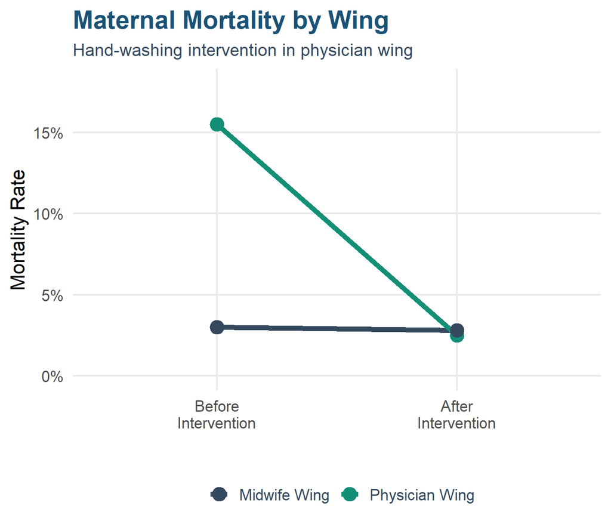

Figure 1: Semmelweis’s natural experiment

```r
semmelweis_data <- tibble(
  period = rep(c("Before\nIntervention", "After\nIntervention"), 2),
  group = rep(c("Physician Wing", "Midwife Wing"), each = 2),
  mortality = c(15.5, 2.5, 3.0, 2.8)
) %>%
  mutate(period = factor(period, levels = c("Before\nIntervention", "After\nIntervention")))

ggplot(semmelweis_data, aes(x = period, y = mortality,
                            color = group, group = group)) +
  geom_line(linewidth = 2) +
  geom_point(size = 5) +
  scale_color_manual(values = c("Midwife Wing" = slate_gray, "Physician Wing" = secondary_teal), name = "") +
  scale_y_continuous(labels = label_percent(scale = 1), limits = c(0, 18)) +
  labs(
    title = "Maternal Mortality by Wing",
    subtitle = "Hand-washing intervention in physician wing",
    x = "", y = "Mortality Rate"
  ) +
  theme_health_econ(base_size = 16) +
  theme(legend.position = "bottom")
```

## Semmelweis’s Intervention Changed Everything

**The Intervention:**

Instituted hand-washing with chlorine solution for physicians (but not midwives)

**The Result:**

A natural DiD design — mortality dropped dramatically in the physician wing while staying stable in the midwife wing

**Why this is DiD:**

- **Treatment group:** Physician wing (received hand-washing)
- **Control group:** Midwife wing (no change)
- **Before vs. after:** Mortality before and after the intervention

## The Cost of Being Right Too Early

**Evidence Rejected**

Despite compelling evidence, Semmelweis’s findings were dismissed.

His superiors attributed improvements to **changes in ventilation** — not hand-washing.

**Semmelweis faced professional ruin and died in an asylum.**

**A Parallel Trends Objection Before Its Time**

The ventilation critique was essentially a **parallel trends violation claim**: “Both wings would have improved due to better ventilation — the physician wing just happened to get it first.”

If Semmelweis had the vocabulary of parallel trends, could he have defended his findings more convincingly?

It took another 20 years for germ theory to become accepted.

## The Second Detective: John Snow (1854)

**The Crisis:**

- Three major cholera waves devastated London
- Dominant theory: **Miasma** (bad air causes disease)

**Snow’s Insight:**

Cholera was **waterborne**, not airborne — transmitted through contaminated Thames water

## Snow’s Natural Experiment

**The Setup:**

- London ordered water companies to move intake pipes upstream
- Companies complied at **different times**
- **Lambeth** moved pipes in 1852; **Southwark & Vauxhall** didn’t until later

**The Identification:**

Same neighborhoods, different water sources — a **natural DiD design**

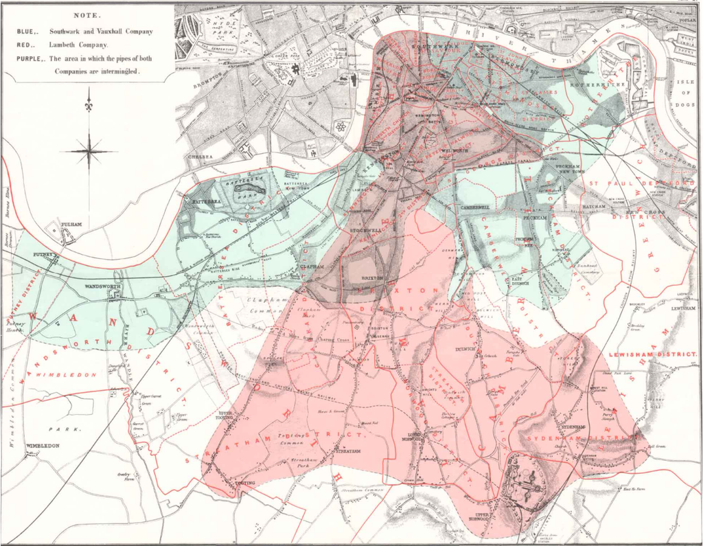

Map of London water utilities, 1854

## Snow’s Table: The First DiD Calculation

Table 1

| Company | Period | Deaths per 10,000 | Outcome Expression | First Difference |
| --- | --- | --- | --- | --- |
| **Lambeth** | Before (1849) | 150 | $Y = L$ |  |
| **Lambeth** | After (1854) | 37 | $Y = L + {\color{#e74c3c}{L_t}} + D$ | $D + {\color{#e74c3c}{L_t}}$ |
| **Southwark & Vauxhall** | Before (1849) | 118 | $Y = SV$ |  |
| **Southwark & Vauxhall** | After (1854) | 147 | $Y = SV + SV_t$ | $SV_t$ |

## Snow’s Numbers Tell the Story

**The DiD Calculation (with numbers):**

$$\delta^{DiD} = (37 - 150) - (147 - 118) = -113 - 29 = \mathbf{-142} \text{ deaths per 10,000}$$

**The DiD Calculation (with algebra):**

$$\delta^{DiD} = \Big[(L + {\color{#e74c3c}{L_t}} + D) - L\Big] - \Big[(SV + SV_t) - SV\Big] = D + ({\color{#e74c3c}{L_t}} - SV_t)$$

If ${\color{#e74c3c}{L_t}} = SV_t$ (parallel trends), then $\delta^{DiD} = D$ — the true treatment effect!

## Two Physicians, One Method

**What Semmelweis and Snow Discovered**

Both physicians were doing the same thing — **comparing changes across groups over time**.

Neither had the formal vocabulary, but both intuitively understood: a single before-after comparison isn’t enough. You need a control group to benchmark against.

**Their legacy:** The difference-in-differences framework formalizes exactly what they discovered.

Snow’s table **is** a DiD table. Now let’s see the same logic expressed in regression form.

## From Motivation to Design

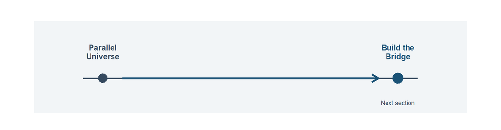

Figure 2

# Building the Bridge Between Universes

The Difference-in-Differences Setup

## Anatomy of the Bridge: Four Averages, Three Subtractions

**Show R Code**

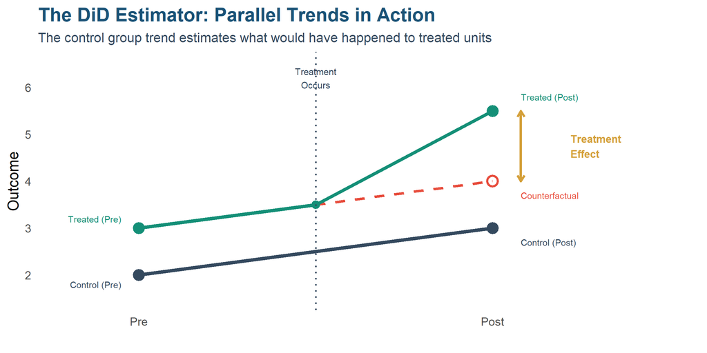

Figure 3: The difference-in-differences estimator

```r
# Create DiD visualization data
did_viz <- tibble(
  time = c(0, 1, 0, 1),
  group = c("Control", "Control", "Treated", "Treated"),
  outcome = c(2, 3, 3, 5.5)
)

# Counterfactual trend for treated units (parallel to control)
cf_line <- tibble(
  time = c(0, 0.5, 1),
  outcome = c(3, 3.5, 4),
  group = "Counterfactual"
)

# Observed treated path:
# follows counterfactual until intervention, then kinks to a new slope
treated_path <- tibble(
  time = c(0, 0.5, 1),
  outcome = c(3, 3.5, 5.5)
)

ggplot() +
  # Control group
  geom_line(data = filter(did_viz, group == "Control"),
            aes(x = time, y = outcome), color = slate_gray, linewidth = 2) +
  geom_point(data = filter(did_viz, group == "Control"),
             aes(x = time, y = outcome), color = slate_gray, size = 6) +
  # Counterfactual
  geom_line(data = cf_line, aes(x = time, y = outcome),
            color = accent_coral, linewidth = 1.5, linetype = "dashed") +
  # Treated group (piecewise with post-treatment kink)
  geom_line(data = treated_path,
            aes(x = time, y = outcome), color = secondary_teal, linewidth = 2) +
  geom_point(data = filter(did_viz, group == "Treated"),
             aes(x = time, y = outcome), color = secondary_teal, size = 6) +
  geom_point(data = filter(treated_path, time == 0.5),
             aes(x = time, y = outcome), color = secondary_teal, size = 4) +
  geom_point(data = filter(cf_line, time == 1),
             aes(x = time, y = outcome), color = accent_coral, size = 5, shape = 1, stroke = 2) +
  # Treatment effect arrow
  annotate("segment", x = 1.08, y = 4, xend = 1.08, yend = 5.5,
           arrow = arrow(length = unit(0.3, "cm"), ends = "both"),
           color = warm_gold, linewidth = 1.5) +
  annotate("text", x = 1.22, y = 4.75, label = "Treatment\nEffect",
           color = warm_gold, fontface = "bold", size = 4.5, hjust = 0) +
  # Labels
  annotate("text", x = -0.05, y = 1.8, label = "Control (Pre)", hjust = 1, color = slate_gray, size = 3.8) +
  annotate("text", x = 1.08, y = 2.7, label = "Control (Post)", hjust = 0, color = slate_gray, size = 3.8) +
  annotate("text", x = -0.05, y = 3.2, label = "Treated (Pre)", hjust = 1, color = secondary_teal, size = 3.8) +
  annotate("text", x = 1.08, y = 5.8, label = "Treated (Post)", hjust = 0, color = secondary_teal, size = 3.8) +
  annotate("text", x = 1.08, y = 3.7, label = "Counterfactual", hjust = 0, color = accent_coral, size = 3.8) +
  # Vertical line at treatment
  geom_vline(xintercept = 0.5, linetype = "dotted", color = slate_gray, linewidth = 1) +
  annotate("text", x = 0.5, y = 6.2, label = "Treatment\nOccurs", color = slate_gray, size = 4) +
  scale_x_continuous(breaks = c(0, 1), labels = c("Pre", "Post"), limits = c(-0.2, 1.5)) +
  scale_y_continuous(limits = c(1.5, 6.5)) +
  labs(
    title = "The DiD Estimator: Parallel Trends in Action",
    subtitle = "The control group trend estimates what would have happened to treated units",
    x = "", y = "Outcome"
  ) +
  theme_health_econ(base_size = 18) +
  theme(panel.grid = element_blank())
```

## The Blueprint: One Regression Captures the Design

**The 2×2 DiD Estimator:**

$$\delta^{DiD} = \underbrace{(Y_{Treated,Post} - Y_{Treated,Pre})}_{\text{Change in treated}} - \underbrace{(Y_{Control,Post} - Y_{Control,Pre})}_{\text{Change in control}}$$

**As a regression:**

$$Y_{it} = \alpha + \beta_1 \cdot \text{Treat}_i + \beta_2 \cdot \text{Post}_t + \delta \cdot (\text{Treat}_i \times \text{Post}_t) + \varepsilon_{it}$$

- $\beta_1$: Baseline difference between groups
- $\beta_2$: Common time trend
- $\delta$: **The DiD estimate** — our causal effect!

**Graduate Students: OLS Equivalence**

The 2×2 DiD can be written as: $\delta = (\bar{Y}_{T,post} - \bar{Y}_{T,pre}) - (\bar{Y}_{C,post} - \bar{Y}_{C,pre})$, which is algebraically identical to the OLS coefficient on $\text{Treat} \times \text{Post}$ in the saturated model.

## The Parallel Universe Test

**The DiD Golden Rule**

Ask yourself: *“If the treatment had never happened, would the treated group have followed the same path as the control group?”*

If the answer is **yes**, the control group is a valid window into the treated group’s alternate universe.

**The Parallel Universe Test checks three things:**

1. **Were the universes aligned before the split?** (If not, parallel trends fails.)
2. **Did anyone peek ahead and change course?** (If yes, the pre-period is contaminated.)
3. **Did anything leak between universes?** (If yes, your control group is partially treated.)

Just as the RDD “Twins Test” asks *“Would these two people be indistinguishable without the cutoff?”*, the Parallel Universe Test asks *“Would these two groups have traveled the same road without the policy?”*

## The Bridge Works Only If the Universes Were Aligned

**Express DiD in potential outcomes notation:**

$$\delta^{DiD} = \underbrace{E[Y^1_{Treated} - Y^0_{Treated}]}_{\text{ATT (what we want)}} + \underbrace{\Big[E[\Delta Y^0_{Treated}] - E[\Delta Y^0_{Control}]\Big]}_{\text{Bias if trends differ}}$$

**The Key Insight**

DiD gives us the **Average Treatment Effect on the Treated (ATT)** only if the bias term equals zero.

This happens when **parallel trends** holds.

**Graduate Students: Formal Identification Result**

Under parallel trends: $E[\Delta Y^0 | D=1] = E[\Delta Y^0 | D=0]$, we have $\delta^{DiD} = ATT$. The bias term $E[\Delta Y^0_{Treated}] - E[\Delta Y^0_{Control}]$ equals zero by assumption.

## From Setup to Assumptions

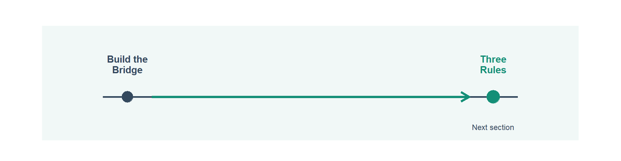

Figure 4

# Three Rules for Parallel Universes

Parallel Trends, No Anticipation, No Spillovers

## The Three Assumptions at a Glance

Table 2

| # | Assumption | What It Means | Testable | If Violated... |
| --- | --- | --- | --- | --- |
| 1 | Parallel Trends | Without treatment, groups would follow the same trajectory | Partially | DiD estimate is biased |
| 2 | No Anticipation | Units don't change behavior before treatment | Sometimes | Pre-period is contaminated |
| 3 | SUTVA | No spillovers between units; treatment is well-defined | Sometimes | Treatment effect is ill-defined |

## Rule 1: The Universes Must Have Been Aligned

**The Core Assumption**

$$E[\Delta Y^0_{Treated}] = E[\Delta Y^0_{Control}]$$

In the absence of treatment, both groups would have followed the same trajectory.

**What Parallel Trends IS:**

- Control group trend approximates treated counterfactual
- Changes over time would be similar absent treatment

**What It’s NOT:**

- Does not require groups to be similar at baseline
- Does not require random assignment (though that would guarantee it)

**Show R Code**

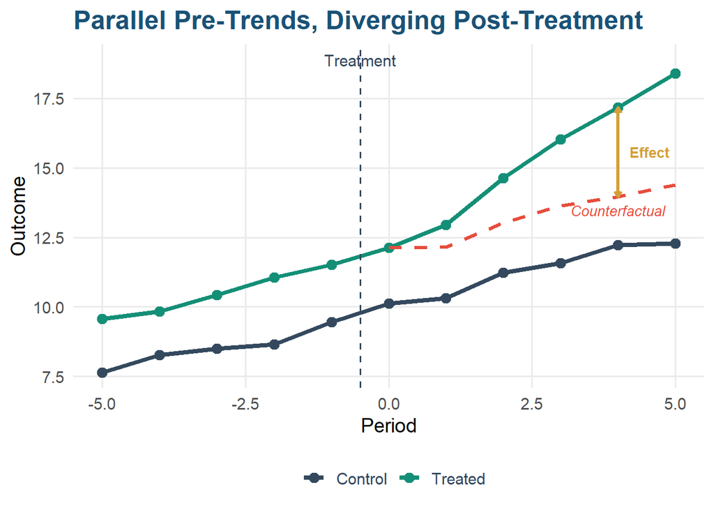

Figure 5: Parallel trends assumption visualized

```r
set.seed(6320)
time <- -5:5

# Both groups share slope 0.5 pre-treatment; treated diverges post
control <- 10 + 0.5 * time + rnorm(11, 0, 0.15)
treated_cf <- 12 + 0.5 * time + rnorm(11, 0, 0.15)  # counterfactual
treat_effect <- ifelse(time >= 0, 0.8 * time, 0)      # growing effect post-treatment
treated <- treated_cf + treat_effect

pt_data <- tibble(
  time = rep(time, 2),
  group = rep(c("Control", "Treated"), each = 11),
  outcome = c(control, treated)
)

# Counterfactual dashed line (what treated would have done)
post_idx <- which(time >= 0)
cf_data <- tibble(time = time[post_idx], outcome = treated_cf[post_idx])

ggplot(pt_data, aes(x = time, y = outcome, color = group)) +
  geom_line(linewidth = 1.5) +
  geom_point(size = 3) +
  geom_line(data = cf_data, aes(x = time, y = outcome),
            color = accent_coral, linewidth = 1.2, linetype = "dashed", inherit.aes = FALSE) +
  geom_vline(xintercept = -0.5, linetype = "dashed", color = slate_gray) +
  scale_color_manual(values = c(slate_gray, secondary_teal), name = "") +
  annotate("text", x = -0.5, y = max(treated) + 0.5, label = "Treatment",
           color = slate_gray, size = 4) +
  annotate("text", x = 4, y = treated_cf[time == 4] - 0.5,
           label = "Counterfactual", color = accent_coral, size = 3.5, fontface = "italic") +
  annotate("segment", x = 4, y = treated_cf[time == 4], xend = 4, yend = treated[time == 4],
           arrow = arrow(length = unit(0.15, "cm"), ends = "both"),
           color = warm_gold, linewidth = 1.2) +
  annotate("text", x = 4.2, y = (treated_cf[time == 4] + treated[time == 4]) / 2,
           label = "Effect", color = warm_gold, fontface = "bold", size = 3.5, hjust = 0) +
  labs(
    title = "Parallel Pre-Trends, Diverging Post-Treatment",
    x = "Period", y = "Outcome"
  ) +
  theme_health_econ(base_size = 14)
```

## Rule 2: No One Peeked into the Future

**Definition**

Units do not change their behavior before treatment in anticipation of it.

**Violations:**

- Buying a house today because you expect a housing subsidy next month
- Hospitals changing staffing before a merger is announced
- Patients stocking up on medications before a policy change

**Why It Matters:**

If the pre-period is already affected, we don’t have a clean baseline for comparison

**Show R Code**

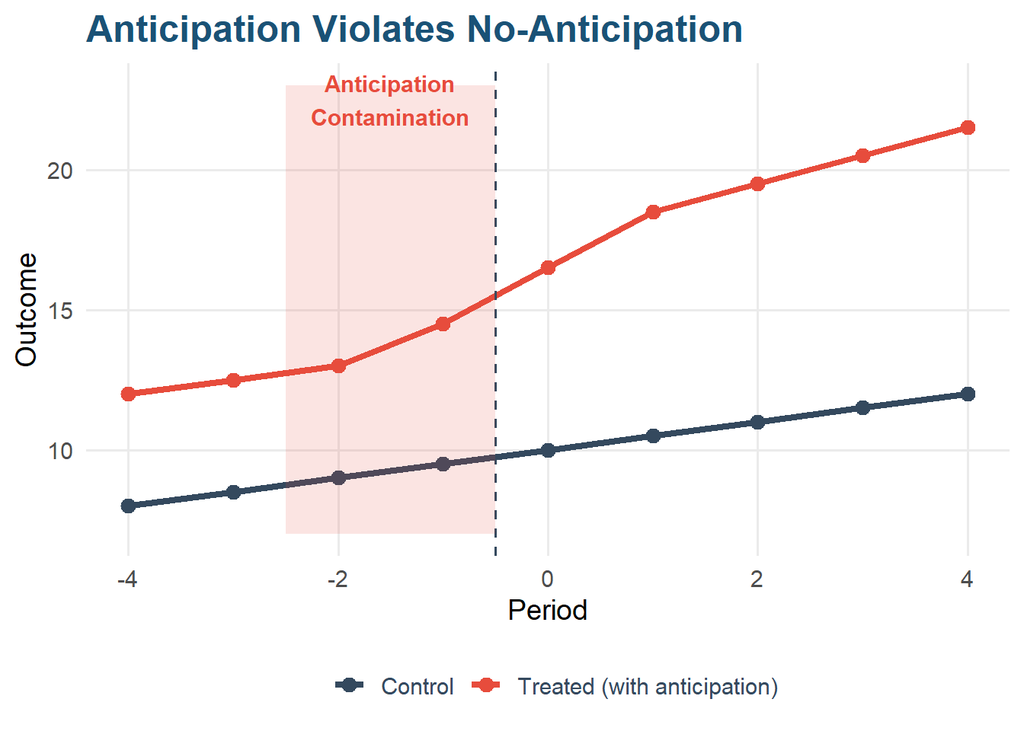

Figure 6: Anticipation effects contaminate the baseline

```r
antic_data <- tibble(
  time = rep(-4:4, 2),
  group = rep(c("Control", "Treated (with anticipation)"), each = 9),
  outcome = c(
    10 + 0.5 * (-4:4),  # Control: steady slope 0.5
    c(12, 12.5, 13, 14.5, 16.5, 18.5, 19.5, 20.5, 21.5)  # Treated: parallel until t=-2, then jumps
  )
)

ggplot(antic_data, aes(x = time, y = outcome, color = group)) +
  geom_line(linewidth = 1.5) +
  geom_point(size = 3) +
  geom_vline(xintercept = -0.5, linetype = "dashed", color = slate_gray) +
  annotate("rect", xmin = -2.5, xmax = -0.5, ymin = 7, ymax = 23,
           fill = accent_coral, alpha = 0.15) +
  annotate("text", x = -1.5, y = 22.5, label = "Anticipation\nContamination",
           color = accent_coral, size = 4, fontface = "bold") +
  scale_color_manual(values = c(slate_gray, accent_coral), name = "") +
  labs(
    title = "Anticipation Violates No-Anticipation",
    x = "Period", y = "Outcome"
  ) +
  theme_health_econ(base_size = 14)
```

## Rule 3: The Universes Don’t Leak

**Stable Unit Treatment Value Assumption**

1. **No interference:** One unit’s treatment doesn’t affect another’s outcome
2. **No hidden variation:** Treatment is applied consistently across units

**Potential Violations:**

- Hospital in treated state affects patients in control state (geographic spillovers)
- New policy changes market equilibrium (general equilibrium effects)
- Treatment intensity varies across “treated” units

**Why It Matters:**

- If spillovers exist, the “control” group is partially treated
- DiD underestimates the true effect
- Need to think carefully about unit of analysis

## From Assumptions to Violations

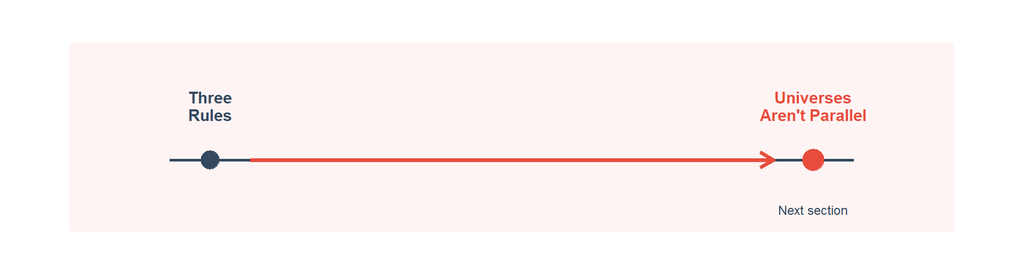

Figure 7

# When the Universes Aren’t Parallel

How and Why DiD Breaks

## Semmelweis’s Critics Broke Rule 1

His critics claimed improved **ventilation** — not hand-washing — caused mortality to drop.

**What they were really arguing:**

“The midwife wing would have improved too if it had gotten better ventilation. You can’t attribute the improvement to hand-washing.”

**This is a parallel trends violation claim.** They argued the counterfactual trend for the physician wing differed from the observed control trend.

**The Stakes of Parallel Trends**

Without the vocabulary to defend parallel trends, Semmelweis lost the argument — and thousands more mothers died.

Modern DiD gives us tools to preemptively address these objections.

## The Shapeshifter: When Your Window Changes Shape

**The Problem**

The composition of your sample changes over time in ways correlated with treatment.

**Example: Hong et al. (2013) — Napster and Music Sales**

- Study uses Consumer Expenditure Survey data on music spending
- Compares internet users vs. non-users before/after Napster (June 1999)
- **Problem:** Who uses the internet changed dramatically over this period!

## Hong et al.: The Window Shifted

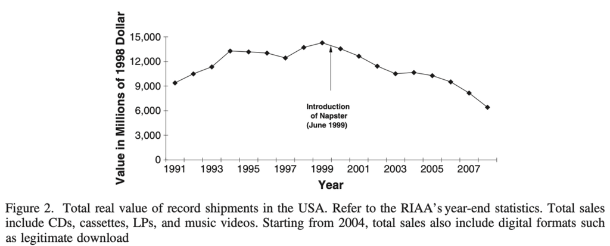

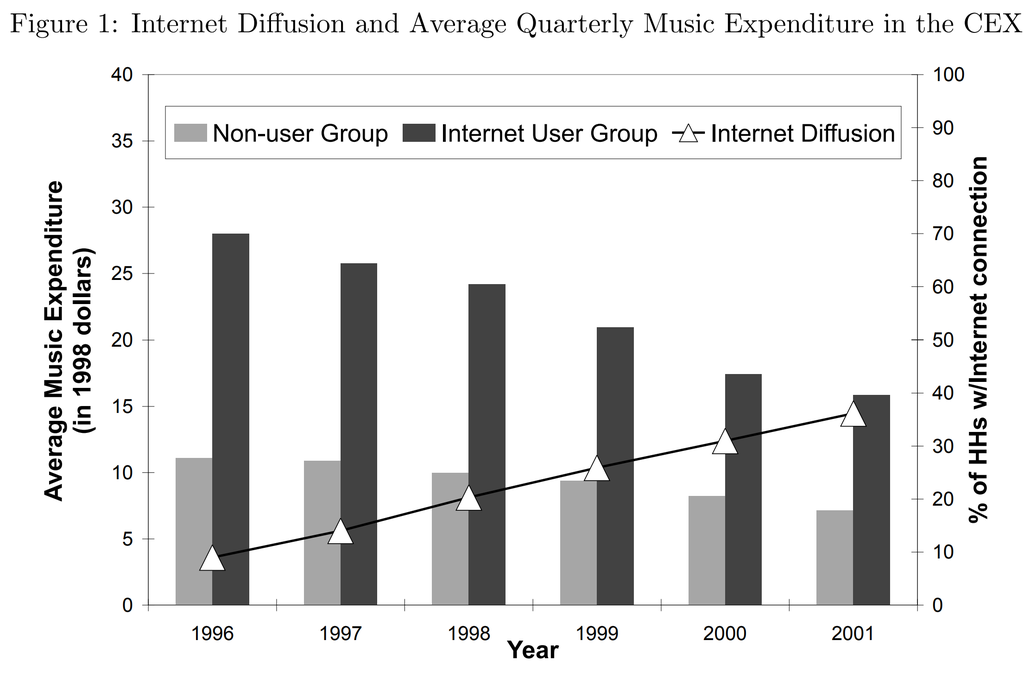

Demographic shifts between periods

**The Issue:** Early internet adopters were young music fans. As internet diffused, the “internet user” group became less music-focused.

## The Demographics Tell the Story

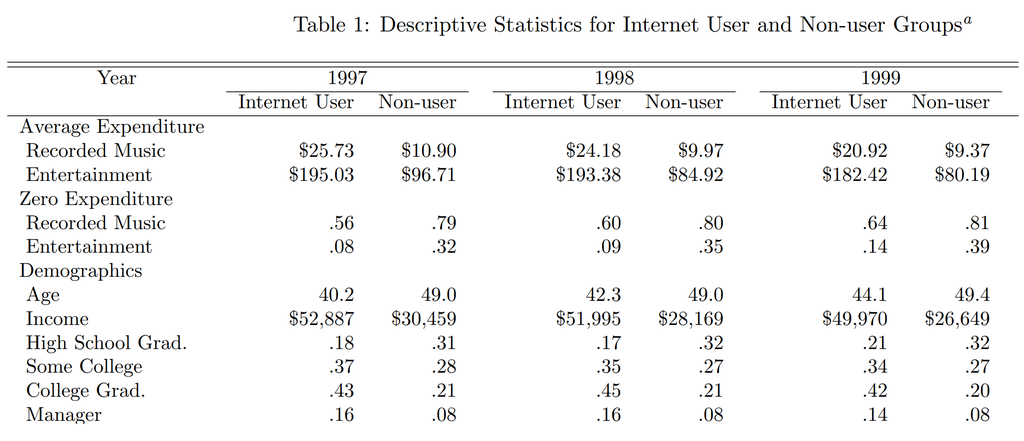

Demographic characteristics by period

**Important**

Compositional changes can make parallel trends fail even if the underlying causal effect is real.

## The Crystal Ball: When Policy Sees the Future

**The Problem**

Policies are enacted in response to pre-existing trends, not randomly.

**Examples:**

- States with rising obesity rates pass soda taxes
- Hospitals with declining quality join health systems
- Cities with rising crime adopt new policing strategies

**The Issue:**

The very trends that prompted the policy violate parallel trends

**Show R Code**

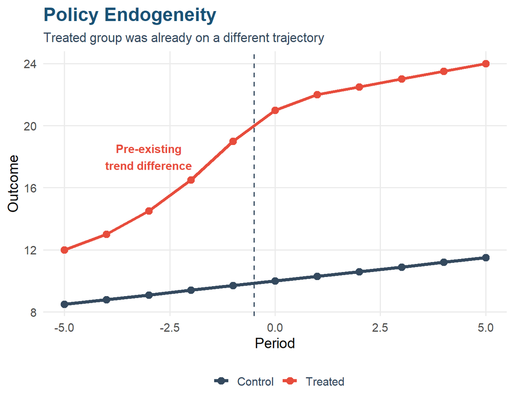

Figure 8

```r
endo_data <- tibble(
  time = rep(-5:5, 2),
  group = rep(c("Control", "Treated"), each = 11),
  outcome = c(
    10 + 0.3 * (-5:5),  # Control - steady growth
    c(12, 13, 14.5, 16.5, 19, 21, 22, 22.5, 23, 23.5, 24)  # Treated - was growing faster, policy slows it
  )
)

ggplot(endo_data, aes(x = time, y = outcome, color = group)) +
  geom_line(linewidth = 1.5) +
  geom_point(size = 3) +
  geom_vline(xintercept = -0.5, linetype = "dashed", color = slate_gray) +
  annotate("text", x = -3, y = 18, label = "Pre-existing\ntrend difference",
           color = accent_coral, size = 4, fontface = "bold") +
  scale_color_manual(values = c(slate_gray, accent_coral), name = "") +
  labs(
    title = "Policy Endogeneity",
    subtitle = "Treated group was already on a different trajectory",
    x = "Period", y = "Outcome"
  ) +
  theme_health_econ(base_size = 14)
```

## The Ghost: Invisible Forces Push the Universes Apart

**The Problem**

Missing factors that differentially affect treated and control groups over time.

**Common scenarios:**

- Economic shocks hit regions differently
- Demographic changes vary across areas
- Other policies implemented simultaneously

**Solution:** Conditional parallel trends — control for covariates that restore parallel trends assumption:

$$E[\Delta Y^0_{Treated} | X] = E[\Delta Y^0_{Control} | X]$$

## From Violations to Diagnostics

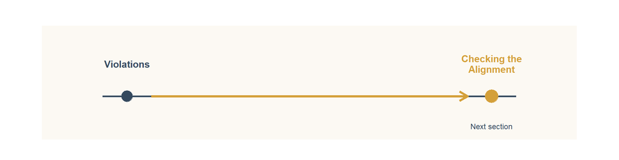

Figure 9

# Checking the Alignment

Event Studies and Pre-Trend Diagnostics

## Can You Trust Your Window?

**The Fundamental Challenge**

Parallel trends is **untestable** — we never observe the treated counterfactual.

But we can examine **pre-treatment trends** as a diagnostic.

**The Logic:**

- If groups had parallel trends before treatment, they might after too
- If pre-trends differ, we should be very worried
- Event studies also show **dynamic treatment effects** over time

**Learning from Semmelweis**

Event studies exist because we’ve learned from cases like Semmelweis. We need to **preemptively address** the parallel trends objection — not wait for critics to raise it after the fact.

## The Alignment Check: Event Study Regression

$$\begin{aligned}
Y_{it} = \gamma_i + \lambda_t &+ \sum_{\tau=-q}^{-2} \mu_{\tau} (D_i \times \mathbf{1}\{\tau_t = \tau\})
+ \sum_{\tau=0}^{m} \delta_{\tau} (D_i \times \mathbf{1}\{\tau_t = \tau\}) + \varepsilon_{it}
\end{aligned}$$

**Components:**

- $\gamma_i$: Unit fixed effects
- $\lambda_t$: Time fixed effects
- $\mu_{\tau}$: Pre-treatment coefficients (should be ~0)
- $\delta_{\tau}$: Post-treatment effects (our estimates)

**Key points:**

- Omit one period (usually $\tau = -1$) as reference
- Pre-period $\mu$’s test for differential pre-trends
- Post-period $\delta$’s trace dynamic treatment effects

**Important Caveat**

$\mu_{\tau} = 0$ does NOT prove parallel trends holds — only that we can’t detect a violation.

## Reading the Alignment Scan

**Show R Code**

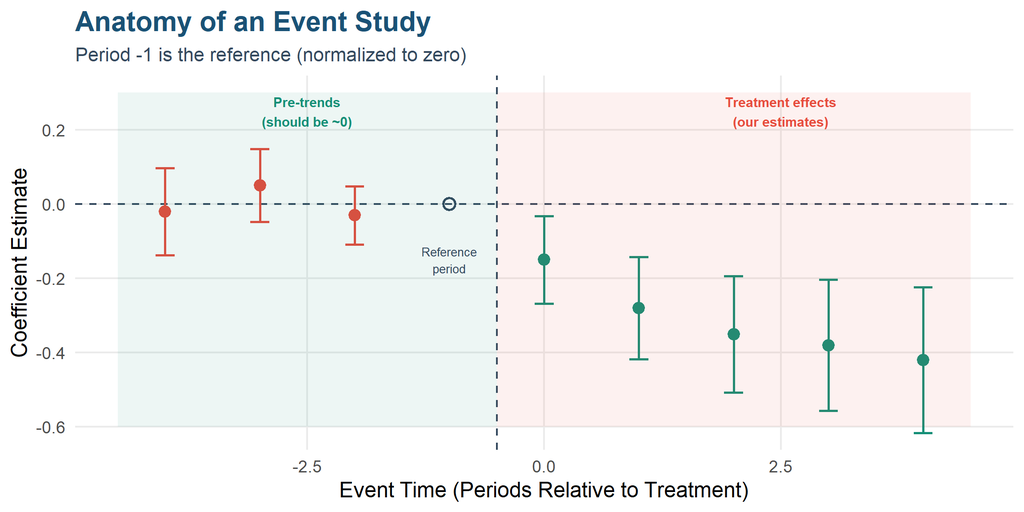

Figure 10: Interpreting event study coefficients

```r
set.seed(6320)
event_time <- -4:4
coeff <- c(-0.02, 0.05, -0.03, 0, -0.15, -0.28, -0.35, -0.38, -0.42)
se <- c(0.06, 0.05, 0.04, NA, 0.06, 0.07, 0.08, 0.09, 0.10)

event_data <- tibble(
  period = event_time,
  estimate = coeff,
  se = se,
  lower = coeff - 1.96 * se,
  upper = coeff + 1.96 * se,
  phase = ifelse(period < 0, "Pre-Treatment", "Post-Treatment")
)

ggplot(event_data, aes(x = period, y = estimate)) +
  geom_hline(yintercept = 0, linetype = "dashed", color = slate_gray) +
  geom_vline(xintercept = -0.5, linetype = "dashed", color = slate_gray) +
  geom_errorbar(data = filter(event_data, period != -1),
                aes(ymin = lower, ymax = upper, color = phase), width = 0.2, linewidth = 1) +
  geom_point(data = filter(event_data, period != -1),
             aes(color = phase), size = 4) +
  geom_point(data = filter(event_data, period == -1),
             shape = 1, size = 4, color = slate_gray, stroke = 1.5) +
  scale_color_manual(values = c(secondary_teal, accent_coral), name = "") +
  annotate("rect", xmin = -4.5, xmax = -0.5, ymin = -0.6, ymax = 0.3,
           fill = secondary_teal, alpha = 0.08) +
  annotate("rect", xmin = -0.5, xmax = 4.5, ymin = -0.6, ymax = 0.3,
           fill = accent_coral, alpha = 0.08) +
  annotate("text", x = -2.5, y = 0.25, label = "Pre-trends\n(should be ~0)",
           color = secondary_teal, size = 4, fontface = "bold") +
  annotate("text", x = 2.5, y = 0.25, label = "Treatment effects\n(our estimates)",
           color = accent_coral, size = 4, fontface = "bold") +
  annotate("text", x = -1, y = -0.15, label = "Reference\nperiod",
           color = slate_gray, size = 3.5) +
  labs(
    title = "Anatomy of an Event Study",
    subtitle = "Period -1 is the reference (normalized to zero)",
    x = "Event Time (Periods Relative to Treatment)",
    y = "Coefficient Estimate"
  ) +
  theme_health_econ(base_size = 18) +
  theme(legend.position = "none")
```

**Graduate Students: Pre-Testing Pitfalls**

Roth (2022) shows that conditioning on passing a pre-trends test can distort inference. Pre-trends tests have low power against violations that would meaningfully bias the DiD estimate. The absence of evidence is not evidence of absence.

## From Diagnostics to Modern DiD

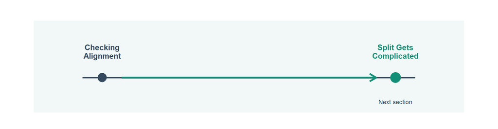

Figure 11

# When the Split Gets Complicated

Staggered Adoption and New Estimators

## When Everyone Enters Their Universe at Different Times

**The Modern DiD Challenge**

Many studies have staggered adoption: different units receive treatment at different times.

The standard two-way fixed effects (TWFE) estimator can be **severely biased** in this setting.

**The Standard Approach:**

$$Y_{it} = \delta D_{it} + \alpha_i + \gamma_t + \varepsilon_{it}$$

- $\alpha_i$: Unit fixed effects
- $\gamma_t$: Time fixed effects
- $D_{it}$: Treatment indicator

**The Problem:**

- TWFE is a weighted average of many 2×2 comparisons
- Some comparisons use **already-treated** units as controls
- Some weights can be **negative**!

## TWFE Uses Already-Treated Units as Controls

Table 3

| Comparison | Control Group | Problem |
| --- | --- | --- |
| Early vs. Never Treated | Never treated | Clean |
| Late vs. Never Treated | Never treated | Clean |
| Early vs. Late (Not-Yet-Treated) | Late treated (pre-treatment period) | Clean |
| Early vs. Late (Already Treated) | Early treated (post-treatment period) | PROBLEMATIC - treated units used as controls |

**Key insight:** When early-treated units serve as “controls” for late-treated units, and treatment effects grow over time, TWFE can even get the **wrong sign**.

**Graduate Students: Goodman-Bacon Decomposition**

The TWFE coefficient $\hat{\delta}$ is a weighted average: $\hat{\delta} = \sum_{k} w_k \hat{\delta}_k$ where weights $w_k$ depend on group sizes and timing variance. Negative weights arise when already-treated groups serve as controls, which can reverse the sign of the estimate.

## Modern Estimators Fix the Staggered Problem

Table 4

| Method | Key Innovation | Best For |
| --- | --- | --- |
| Callaway & Sant'Anna (2021) | Estimate group-time ATT(g,t) separately, then aggregate | Heterogeneous effects across cohorts |
| Sun & Abraham (2021) | Interaction-weighted estimator for event studies | Dynamic event study designs |
| De Chaisemartin & d'Haultfoeuille (2020) | Identify conditions when TWFE fails; propose alternative | Diagnosing TWFE problems |

**Practical Advice**

With staggered adoption: (1) Use Bacon decomposition to check for problematic comparisons, (2) Apply modern estimators as robustness checks, (3) Be transparent about which approach you use.

## Advanced Upgrades: Inference and Sensitivity

### Clustered Standard Errors

**Problem:** Serial correlation within units inflates t-statistics

**Solution:** Cluster at the level of treatment assignment (Bertrand, Duflo & Mullainathan, 2004)

### Honest DiD

**Problem:** How robust are results to parallel trends violations?

**Solution:** Rambachan & Roth (2023) bound the ATT under assumptions about maximum pre-trend deviations

**Graduate Students: Wild Cluster Bootstrap**

When the number of clusters is small (< 50), cluster-robust SEs can be severely size-distorted. Cameron, Gelbach & Miller (2008) propose the wild cluster bootstrap. In R: `fwildclusterboot::boottest()`.

## Advanced Upgrades: Triple Differences

### Triple Differences (DDD)

**Problem:** Parallel trends is violated but affects both treatment and placebo groups similarly

**Solution:** Add a third difference to net out the bias:

$$\delta^{DDD} = \delta^{DiD}_{main} - \delta^{DiD}_{placebo}$$

**Example:** Compare age-eligible vs. age-ineligible within treatment vs. control states

## From Methods to Application

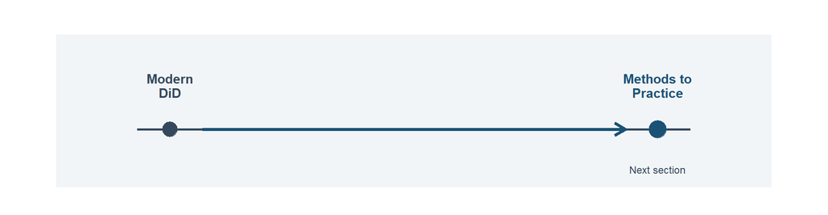

Figure 12

# From Methods to Practice

Applying DiD to Real Policy Evidence

Miller et al. (2019)

## Miller et al. (2019): Discussion Questions

### Skim the paper and think about the following:

1. What is the main research question?
2. What is the treatment and what is the comparison group?
3. How do they establish that the “bite” of the policy was real?
4. What falsification test do they run and why?
5. What are the main results and mechanisms?

**Context**

Under the Affordable Care Act, some states expanded Medicaid while others did not. This creates variation in treatment timing across states.

## The Setting: Did Medicaid Expansion Save Lives?

**The Policy:**

- ACA allowed states to expand Medicaid to adults up to 138% of poverty
- Some states expanded starting in 2014; others did not
- Focus: near-elderly adults (ages 55-64)

**The Question:**

Does Medicaid expansion reduce mortality?

**The Challenge:**

States that expanded may differ systematically from those that didn’t

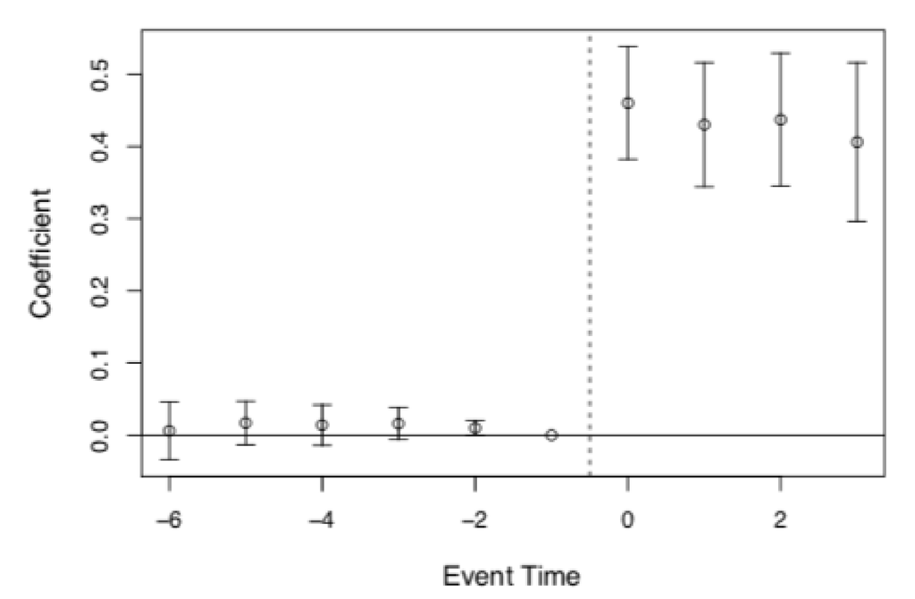

Medicaid eligibility changes

## First Check: Did the Policy Actually Change Anything?

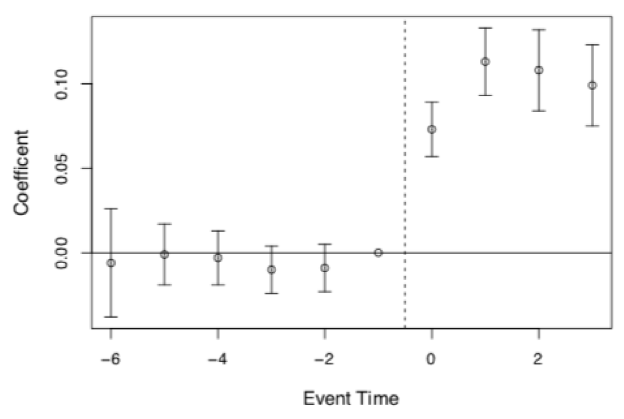

Medicaid coverage increased

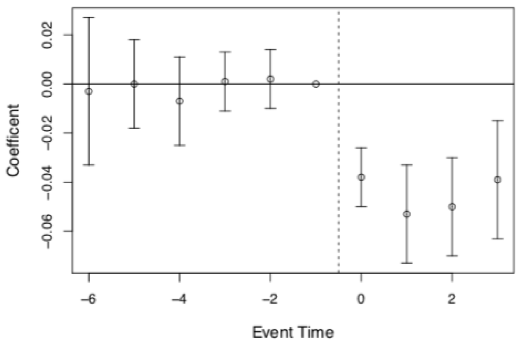

Uninsured rate fell

**The “bite”:** Expansion states saw large increases in Medicaid enrollment and large decreases in uninsurance among the target population.

## The Falsification Test: Looking Through the Wrong Window

**The Logic:**

- Near-elderly (55-64) are the treatment group
- Elderly (65+) are already on Medicare
- If Medicaid expansion affects elderly mortality, something is wrong

**Why This Works:**

- Elderly are exposed to same state-level shocks
- But Medicaid expansion is irrelevant to them
- Finding an effect would suggest confounding

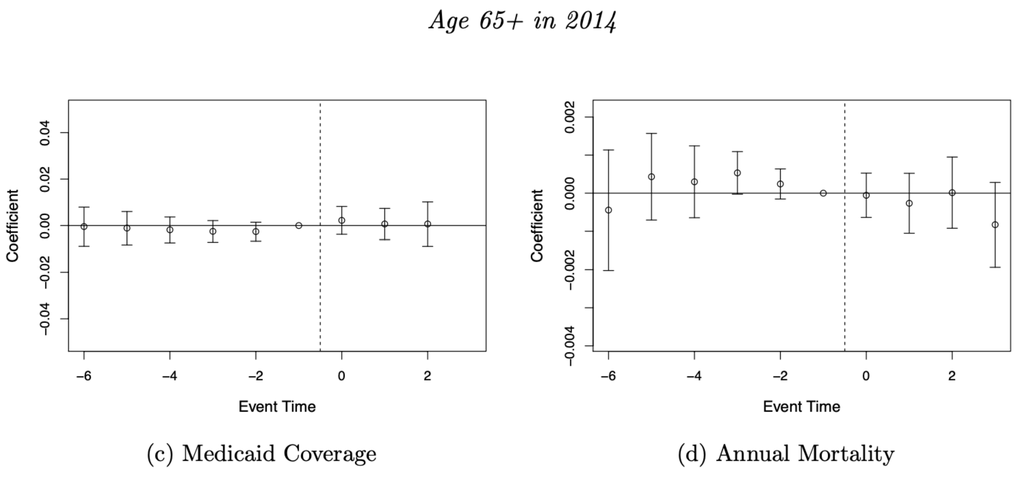

No effect on elderly mortality

## The Verdict: Medicaid Expansion Saved Lives

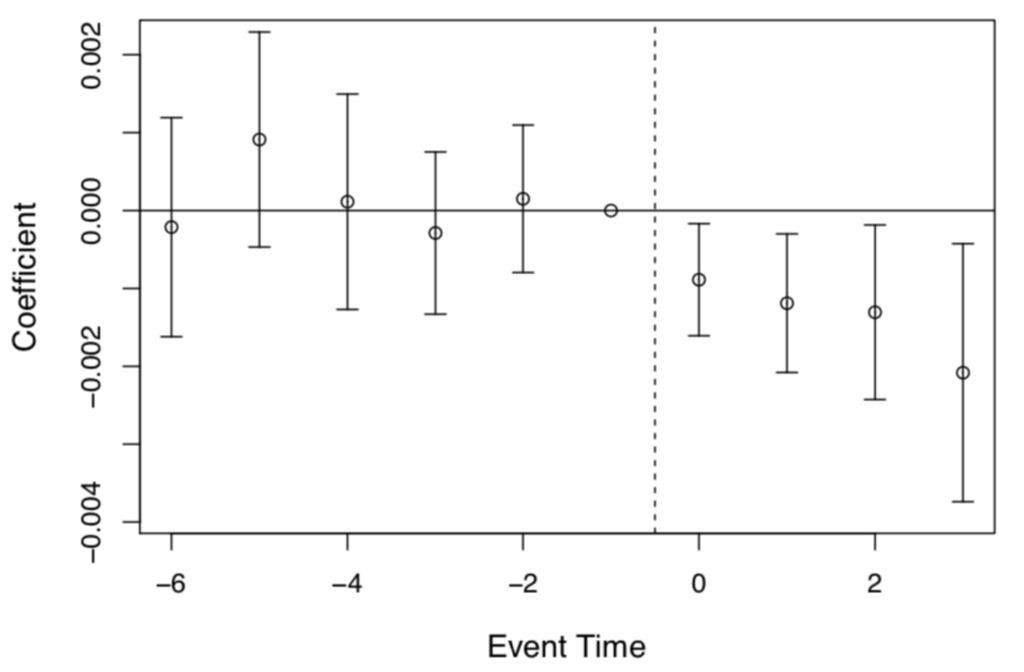

Event study: Mortality declines after expansion

**Key Results:**

- **9.4% reduction** in annual mortality among near-elderly
- **0.13 percentage point** decline in mortality rate
- Roughly **1 death prevented per 239–316** newly insured adults
- Effect driven by **disease-amenable** causes of death

**Event Study Features:**

- Pre-trends are flat (parallel trends supported)
- Effect grows over time (consistent with health insurance improving health)

## Assembling the Evidence Package

Table 5

| Evidence Type | Finding | Supports... |
| --- | --- | --- |
| Bite | Large increase in Medicaid enrollment; large decrease in uninsurance | Policy actually changed insurance coverage |
| Parallel Pre-Trends | Event study shows no differential pre-trends | Parallel trends assumption is plausible |
| Falsification | No effect on elderly (who are on Medicare) | Results not driven by state-level confounders |
| Main Result | 9.4% reduction in mortality among near-elderly | Medicaid expansion saves lives |
| Mechanism | Effect driven by disease-related deaths | Health insurance improves health outcomes |

## From First to Second Application

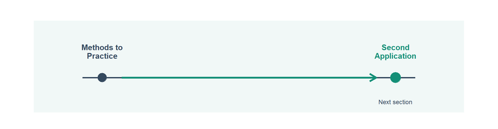

Figure 13

# A Second Application

Extending the Framework to New Settings

Gaynor et al. (2021)

## Gaynor et al. (2021): Discussion Questions

### Skim the paper and think about the following:

1. What is the main research question about hospital mergers?
2. What makes this study’s data unique (hint: surveys)?
3. How do they establish parallel trends in their event study?
4. What is the “new toy” effect and why might it matter?
5. Do the promised efficiencies of the merger materialize?

**Context**

Hospital mergers promise efficiency gains and quality improvements. This study examines whether those promises are kept.

## The Question: Do Hospital Mergers Deliver on Their Promises?

**Paper:** *The Anatomy of a Hospital System Merger: The Patient Did Not Respond Well to Treatment*

**Context:**

- Hospital mergers are increasingly common
- Promised benefits: efficiency gains, quality improvements
- Concerns: market power, higher prices, reduced quality

**Innovation:**

- Combines administrative data with **survey of hospital leadership**
- Opens the “black box” of management practices
- Can compare stated goals vs. actual outcomes

**Research Questions:**

1. Do promised efficiencies materialize?
2. What happens to staffing and quality?
3. How do target hospitals perform post-merger?

## The Evidence: Mergers Hurt More Than They Help

**Key Findings:**

**The “New Toy” Effect (Schoar, 2002):**

- Resources shift to acquired hospitals
- Incumbent divisions suffer
- Net effect may be negative

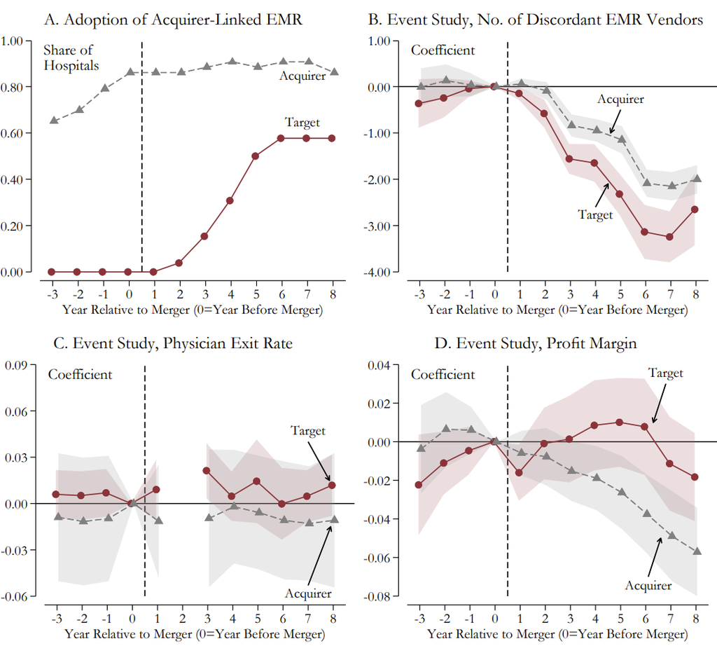

Event study of merger effects

## Two Studies, One Toolkit

### Miller et al. (2019)

**Strengths:**

- Clear policy variation
- Strong falsification test
- Plausible mechanism

**DiD Design Elements:**

- Treatment: State Medicaid expansion
- Control: Non-expansion states
- Pre-trends: Event study shows parallel

### Gaynor et al. (2021)

**Strengths:**

- Rich data on mechanisms
- Management survey adds insight
- Multiple outcome measures

**DiD Design Elements:**

- Treatment: Hospital acquisition
- Control: Non-acquired hospitals
- Pre-trends: Parallel in most outcomes

## From Evidence to Synthesis

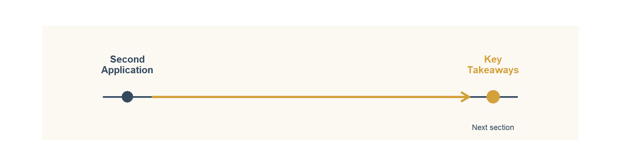

Figure 14

# Key Takeaways

What to Carry into Applied Work

## The Complete Evidence Package

**What to Build:**

- **Bite:** Did the policy actually shift treatment?
- **Pre-trends:** Event study with flat pre-period
- **Falsification:** No effect on groups that shouldn’t be affected
- **Mechanisms:** Does the story make biological/economic sense?
- **Robustness:** Results survive alternative specifications

**What to Watch For:**

- Why did some units get treated and others didn’t?
- What else changed at the same time?
- Diverging pre-trends
- Policy enacted in response to trends
- Compositional changes over time
- Spillovers across groups

## Where Parallel Universes Work Best

| Setting | Treatment | Control | Key Concern |
| --- | --- | --- | --- |
| State policy adoption | Adopting states | Non-adopting states | Policy endogeneity |
| Hospital mergers | Acquired hospitals | Non-acquired | Selection into acquisition |
| Insurance expansions | Newly eligible | Ineligible | Compositional change |
| Payment reforms | Affected providers | Unaffected | Spillovers to controls |
| Geographic variation | Exposed areas | Unexposed areas | Local shocks |

## The Parallel Universe Principle

**The Core Insight**

*“You can never visit the universe where the policy didn’t happen — but if you find a group that was traveling the same path, the gap between their journeys reveals the causal effect.”*

DiD works because:

- **Policy creates a fork** between treated and untreated universes
- **The control group’s journey** approximates the road not taken
- **The gap at the fork** is causal — as long as the universes were truly aligned

## Looking Ahead

RDD exploited a **spatial edge** — comparing units on either side of a cutoff. DiD exploits a **temporal fork** — comparing trajectories before and after treatment.

But what happens when providers use their market position to build walls around their business?

**Next: The Moat — Physician and Hospital Markets**

When providers build moats around their markets — through mergers, consolidation, and vertical integration — who pays the price? We’ll use the causal tools we’ve built to study how market power shapes healthcare delivery.

*From the parallel universe to the moat — our causal toolkit meets industrial organization.*

## Discussion Questions

1. **Design thinking:** You want to study whether hospital price transparency laws reduce healthcare spending. What would be your treatment and control groups? What threats to parallel trends worry you most?
2. **Falsification:** In the Miller et al. study, why is the elderly population a good falsification test? Can you think of another falsification test they could have used?
3. **Staggered adoption:** Many health policies are adopted by states at different times. When does this help identification (more variation) vs. hurt it (TWFE problems)?
4. **Anticipation:** A state announces a hospital price transparency law 18 months before implementation. You plan a DiD study using the implementation date. What could go wrong? How would you adjust your design?

## From Takeaways to Appendix

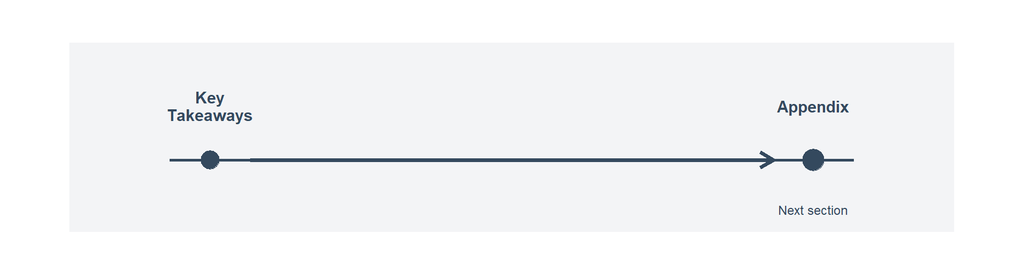

Figure 15

# Appendix: Technical Details

## The Honest DiD Framework

**Rambachan & Roth (2023):** What if parallel trends is slightly violated?

**The Approach:**

1. Measure maximum deviation in pre-treatment coefficients: $\bar{M}$
2. Assume post-treatment violations are bounded: $|\text{bias}| \leq \bar{M}$
3. Construct confidence intervals that account for potential bias

**Interpretation:**

“If post-treatment trend violations are no worse than what we observed pre-treatment, the ATT lies in this interval.”

Provides a **sensitivity analysis** for the parallel trends assumption.

**R Package**

The `HonestDiD` package implements these methods. Increasingly expected in top journals.

## Triple Differences: Formal Setup

**When to use:** Parallel trends is violated, but you have an additional comparison dimension.

$$Y_{igt} = \alpha + \beta_1 \text{Treat}_g + \beta_2 \text{Post}_t + \beta_3 \text{Eligible}_i + \text{(two-way interactions)} + \delta^{DDD} (\text{Treat}_g \times \text{Post}_t \times \text{Eligible}_i) + \varepsilon_{igt}$$

**Example:** Miller et al. could have done:

- $g$: Expansion vs. non-expansion states
- $t$: Pre vs. post-ACA
- $i$: Near-elderly (eligible) vs. elderly (ineligible)

The DDD coefficient nets out any state-time trends common to both age groups.

## Callaway & Sant’Anna (2021): Group-Time ATT

**The Innovation:** Instead of one pooled estimate, estimate ATT for each cohort at each time:

$$ATT(g, t) = E[Y_t(g) - Y_t(\infty) | G = g]$$

where $g$ is the treatment timing group and $Y_t(\infty)$ is the never-treated potential outcome.

**Aggregation Options:**

1. Simple average across $(g,t)$
2. Event-study aggregation (by time since treatment)
3. Cohort-specific effects (by treatment timing)

**R Implementation:**

```r
library(did)
att_gt <- att_gt(
  yname = "outcome",
  tname = "year",
  idname = "id",
  gname = "first_treat",
  data = mydata
)
```

## Inference in DiD: Clustered Standard Errors

**Bertrand, Duflo & Mullainathan (2004):** Standard errors in DiD are often way too small.

**The Problem:**

- Outcomes are serially correlated within units
- Standard errors don’t account for this
- Type I error rates can be 3-4x the nominal level!

**The Solution:**

Cluster standard errors at the level of treatment assignment (usually state or firm).

```r
# In R with fixest
feols(Y ~ treat*post | unit + time, data = df, cluster = "state")
```

**Rule of Thumb**

You need at least 30-50 clusters for cluster-robust inference to work well. With fewer clusters, use wild cluster bootstrap.